# Alpha多样性箱线图Boxplot

Yong-Xin Liu(刘永鑫)

2020/6/7

#### 安装和加载R包：amplicon

检查依赖关系是否安装，有则跳过，无则自动安装。

```r
# 基于github安装包，需要devtools，检测是否存在，不存在则安装
if (!requireNamespace("devtools", quietly = TRUE))
    install.packages("devtools")
# 注：提示安装源码包的最新版时，推荐选否，加速安装预编译的稳定版。原码包编译时间长且容易出错
# 第一次运行，会自动在C:\Users\User\Documents\R\win-library\4.0目录中安装75个包
# 加载github包安装工具
library(devtools)
# 检测amplicon包是否安装，没有从源码安装
if (!requireNamespace("amplicon", quietly = TRUE))
    install_github("microbiota/amplicon")
# 提示升级，选择3 None不升级；升级会容易出现报错
# library加载包，suppress不显示消息和警告信息
suppressWarnings(suppressMessages(library(amplicon)))
```

本项目更新较快，建议使用中存在问题，运行install_github行安装最新版。

#### alpha_boxplot函数

在amplicon包中有alpha_boxplot函数可以一行命令快速绘制箱线图+统计标记的图

本次绘制使用函数内置数据，进行快速演示；查找命令使用，可打问题(?)+命令名。

```r
# 查看函数帮助
?alpha_boxplot
```

```
## starting httpd help server ... done
```

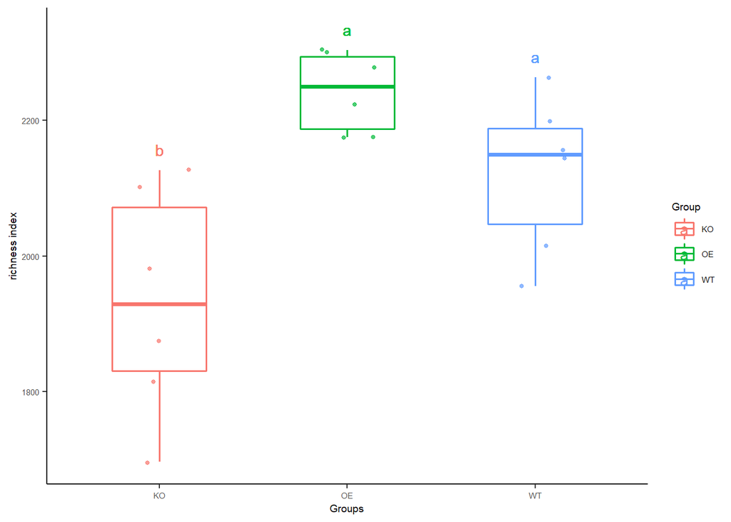

```r
# 使用内置数据，绘制以Group分组下的丰富度指数
(p = alpha_boxplot(alpha_div, metadata, "richness", "Group"))
```

```r
ggsave(paste0("7.png"), p, width=89, height=56, units="mm")
```

图7. 箱线图展示Alpha多样性丰富度(richness)指数在三组内在分布和组间统计。不同字母代表组间存在显著差异(Adjust *P* < 0.05，ANOVA，Tukey HSD test)。

从图中可以看到KO(基因敲除，knock-out)组与OE(过表达，over-expression)和WT(野生型，wild-type)组存在显著差异(字母不同)，即基因的有无可对微生物群落的丰富度引起显著变化。同时观察到丰富度在三组间 KO < WT < OE，根据背景知识这三组的基因表达量也是逐渐升高的，因此可以推断该基因的表达可能在促进菌群丰富度中起重要作用。而且很多研究报导疾病组一般多样性较低，因为可以考虑进一步研究该基因在维持宿主健康中的作用。

#### 绘制精讲

绘制主要分三步：

1. 读取数据并预览格式;
2. 参数调整和绘图;
3. 保存图片。

本次测试数据来自我们负责分析的一篇2019年发表于Science的文章(即上图展示的内置数据)，讨论了基因型对菌群的影响。详见 [Science：拟南芥三萜化合物特异调控根系微生物组](https://mp.weixin.qq.com/s/KmMDEmptBKz8Fv7VSdz2Jg)

原文实验较复杂，这是只截取了3个实验组各6个样品的结果用于演示。数据位于`Data/Science2019`目录，本次需要元数据(metadata.txt)和Alpha多样性指数(alpha/vegan.txt)两个输入文件。

```r
# 读取元数据，参数指定包括标题行(TRUE)，列名为1列，制表符分隔，无注释行，不转换为因子类型
metadata = read.table("../Data/Science2019/metadata.txt", header=T, row.names=1, sep="\t", comment.char="", stringsAsFactors = F)
# 预览元数据前3行，注意分组列名
head(metadata, n = 3)
```

```
##     Group      Date      Site        CRA       CRR BarcodeSequence
## KO1    KO 2017/6/30  Chaoyang CRA002352  CRR117575      ACGCTCGACA
## KO2    KO 2017/6/30  Chaoyang CRA002352  CRR117576      ATCAGACACG
## KO3    KO  2017/7/2 Changping  CRA002352 CRR117577      ATATCGCGAG
##     LinkerPrimerSequence      ReversePrimer Batch              Species
## KO1  AACMGGATTAGATACCCKG ACGTCATCCCCACCTTCC     1 Arabidopsis thaliana
## KO2  AACMGGATTAGATACCCKG ACGTCATCCCCACCTTCC     1 Arabidopsis thaliana
## KO3  AACMGGATTAGATACCCKG ACGTCATCCCCACCTTCC     1 Arabidopsis thaliana
##     Sequencing  Platform           Description
## KO1   Novagene HiSeq2500 Knock-out replicate 1
## KO2   Novagene HiSeq2500 Knock-out replicate 2
## KO3   Novagene HiSeq2500 Knock-out replicate 3
```

```r
# 读取vegan计算6种alpha多样性指数，计算方法见"分析流程 - 扩增子"部分
alpha_div = read.table("../Data/Science2019/alpha/vegan.txt", header=T, row.names=1, sep="\t", comment.char="")
# 预览多样性指数前3行，注释各指数列名
head(alpha_div, n = 3)
```

```
##     richness    chao1      ACE  shannon   simpson invsimpson
## KO1     2125 2432.412 2443.642 6.036140 0.9897723   97.77403
## KO2     2089 2429.512 2419.509 6.074251 0.9913350  115.40716
## KO3     1756 2060.862 2072.541 5.726450 0.9882047   84.77983
```

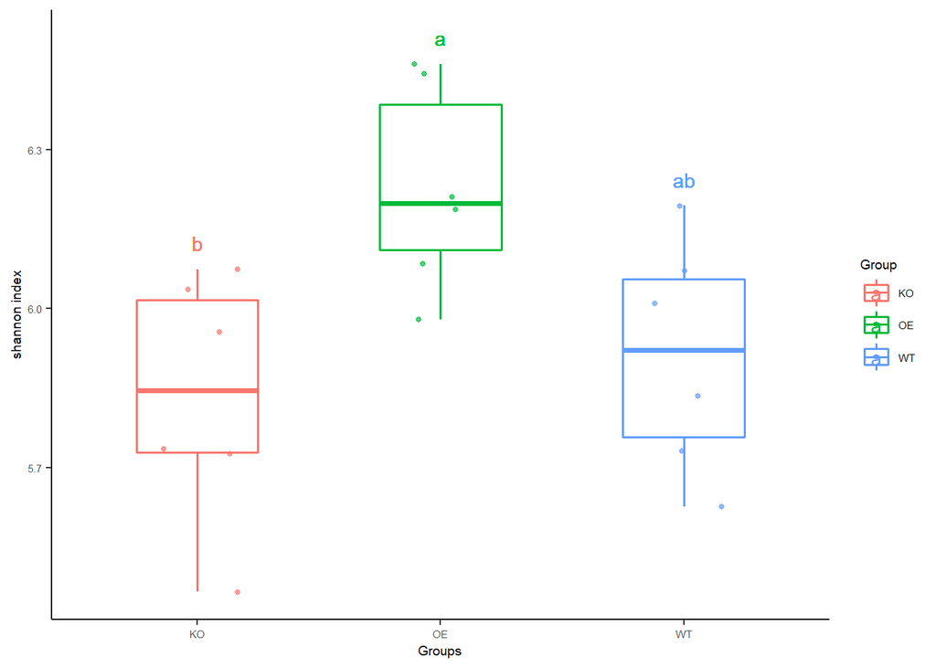

```r
# 绘制各组香农指数分布，外层()可对保存的图形同时预览
(p = alpha_boxplot(alpha_div, index = "shannon", metadata, groupID = "Group"))
```

```r
# 保存图片，指定图片为pdf格式方便后期修改，图片宽89毫米，高56毫米
ggsave(paste0("alpha_boxplot_shannon.pdf"), p, width=89, height=56, units="mm")
ggsave(paste0("8.png"), p, width=89, height=56, units="mm")
```

图8. 箱线图展示Alpha多样性香农(shannon)指数在三组内在分布和组间统计。

#### 常用技巧

**修改分组顺序**

我们经常要按照一定的逻辑指定分组顺序。如图7中发列多样性分布存在一定规律，我们想按多样性由小至大顺序手动重排分组。在R语言中，可以通过设置level来指定顺序

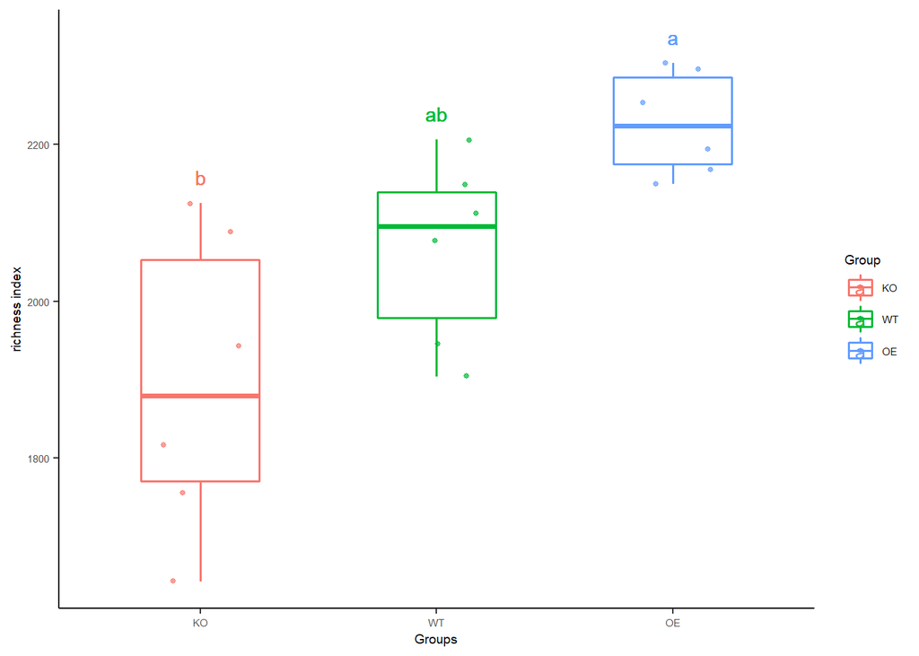

```r
metadata$Group = factor(metadata$Group, levels = c("KO","WT","OE"))
(p = alpha_boxplot(alpha_div, metadata, "richness", "Group"))
```

```r
ggsave(paste0("9.png"), p, width=89, height=56, units="mm")
```

图9. 手动指定分组顺序，表达观察到的规律。

**讨论干扰因素是否显著影响多样性**

实验中还可能涉及多时间、多地点、不同测序批次、序列标签、DNA提取方法不同等多种混淆因子。如果有分组内存在以上因素，判断它们是否引起群落多样性的变化是至关重要的。本研究中每个批次还涉及多个实验地点，以判断不同实验地点或批次是否会结果有影响。我们将分组列指定为地点(Site)

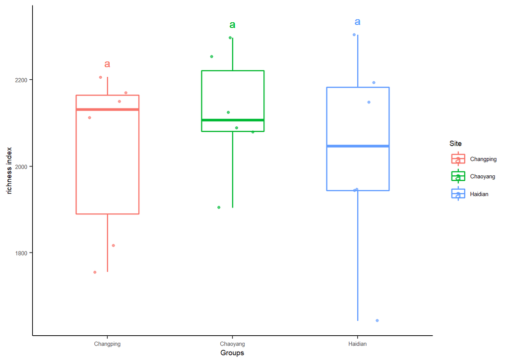

```r
(p = alpha_boxplot(alpha_div, metadata, "richness", "Site"))
```

```r
ggsave(paste0("10.png"), p, width=89, height=56, units="mm")
```

图10. 讨论不同地点是否对Alpha多样性存在影响，图中显示无显著影响。

**查看函数原代码进一步修改**

只输入函数名称，不加后面的括号和任何参数，即显示函数的全部代码。

你可以复制输出的代码，在文档中修改更加个性化的分析结果。

```r
alpha_boxplot
```

```
## function(alpha_div, metadata, index = "richness", groupID = "Group") {
##
##   # 依赖关系检测与安装
##   p_list = c("ggplot2", "dplyr", "multcompView") # "agricolae"
##   for(p in p_list){
##     if (!requireNamespace(p)){
##     install.packages(p)}
##     suppressPackageStartupMessages(library(p, character.only = TRUE, quietly = TRUE, warn.conflicts = FALSE))
##   }
##
##   # 测试默认参数
##   # library(amplicon)
##   # index = "richness"
##   # groupID = "Group"
##   # metadata = subset(metadata, Group %in% c("KO","OE"))
##
##   # 交叉筛选
##   idx = rownames(metadata) %in% rownames(alpha_div)
##   metadata = metadata[idx,]
##   alpha_div = alpha_div[rownames(metadata),]
##
##   # 提取样品组信息,默认为group可指定
##   sampFile = as.data.frame(metadata[, groupID],row.names = row.names(metadata))
##   # colnames(sampFile)[1] = "group"
##
##   # 合并alpha_div和metadata
##   df = cbind(alpha_div[rownames(sampFile),index], sampFile)
##   colnames(df) = c(index,"group")
##
##   # 统计各种显著性
##   model = aov(df[[index]] ~ group, data=df)
##   # 计算Tukey显著性差异检验
##   Tukey_HSD = TukeyHSD(model, ordered = TRUE, conf.level = 0.95)
##   # 提取比较结果
##   Tukey_HSD_table = as.data.frame(Tukey_HSD$group)
##
##   # 保存统计结果
##   # 保存一个制表符，解决存在行名时，列名无法对齐的问题
##   write.table(paste(date(), "\nGroup\t", groupID, "\n\t", sep=""), file=paste("alpha_boxplot_TukeyHSD.txt",sep=""),append = T, quote = F, eol = "", row.names = F, col.names = F)
##   # 保存统计结果，有warning正常
```

[output cut: 39 more lines]

```
##   y=as.data.frame(y)
##   rownames(y)=y$group
##   df$y=y[as.character(df$group),]$Max + (max-min)*0.05
##
##   # 绘图 plotting
##   p = ggplot(df, aes(x=group, y=df[[index]], color=group)) +
##     geom_boxplot(alpha=1, outlier.shape = NA, outlier.size=0, size=0.7, width=0.5, fill="transparent") +
##     labs(x="Groups", y=paste(index, "index"), color=groupID) + theme_classic() +
##     geom_text(data=df, aes(x=group, y=y, color=group, label=stat)) +
##     geom_jitter(position=position_jitter(0.17), size=1, alpha=0.7)+
##     theme(text=element_text(family="sans", size=7))
##   p
## }
## <bytecode: 0x0000000014784cc8>
## <environment: namespace:amplicon>
```

#### 柱状图要误差棒

大多数情况下还是推荐箱线图的，但有时觉得箱线图用的太多，审美疲劳。或是数据分布过散，规律不明显时，也可以尝试使用历史更加悠久的柱状图+误差棒

```
## [1] "Statistic table is in alpha_boxplot_TukeyHSD.txt"
```

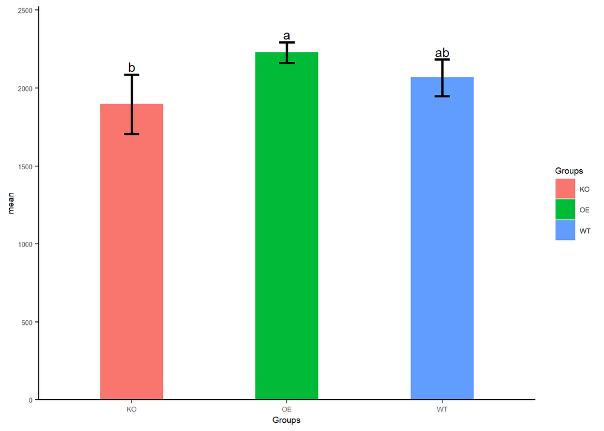

```r
(p = alpha_barplot(alpha_div, index = "richness", metadata, groupID = "Group"))
```

```r
ggsave(paste0("11.png"), p, width=89, height=56, units="mm")
```

图11. 误差柱状图展示Alpha多样性。

如果你使用本教程的代码，请引用:

- [Yong-Xin Liu, Yuan Qin, Tong Chen, et. al. A practical guide to amplicon and metagenomic analysis of microbiome data. Protein Cell 41, 1-16, doi:10.1007/s13238-020-00724-8 (2020)](https://doi.org/10.1007/s13238-020-00724-8)
- [Jingying Zhang, Yong-Xin Liu, et. al. NRT1.1B is associated with root microbiota composition and nitrogen use in field-grown rice. Nature Biotechnology 37, 676-684, doi:10.1038/s41587-019-0104-4 (2019).](https://doi.org/10.1038/s41587-019-0104-4)